# NBA Open Shot Project

Rylee Buchert

2022-08-03

### Introduction

Predicted stats provided analysts a way to gauge player performance based on events that were more likely .

The rise of “three true outcomes” baseball

Any offensive scheme has the goal of generating shots with a high percentage of scoring.

Unfortunately, there is not a wide breadth of public data available to determine what shots have a contesting defender. The NBA uses an array of cameras and tracking software, known as SportsVU, to record game data, but this information is not generally accessible to the public. The good news is that one season’s game tracking data is posted online, conveniently posted on [Kaggle](https://www.kaggle.com/datasets/dansbecker/nba-shot-logs).

This dataset contains the records of over 100,000 shots taken during the 2014-15 NBA season, including information about where the shot was taken, game time, and who was the closest defender. Most importantly, each shot has a measure of how far the closest the closest defender was away from the shooter, providing a way to quantify if each shot had a contesting defender.

### What Counts as an “Open” Shot

Although the concept of an open look makes sense abstractly, it is harder to quantitatively define for data labeling. Ideally, this would include every shot where the shooter is out of reach of the nearest defender. Yet, this idea can vary considerably depending on the defender and court positioning. This makes it sub-optimal to define a set “circle”, say 3~5 feet around a shooter, that defines their open shot zone.

### Obtaining the Data

The first step is to load all of the required R packages and the dataset into the environment. For this project, I utilized the tidyverse, modelr, and ggplot2 R packages.

```r
library(tidyverse)
library(modelr)
library(ggplot2)
library(ggrepel)
shot_data <- read_csv('shot_data.csv')
```

Player wingspan data is not as readily available online as I initially thought it would be. I was only able to find one [website](https://www.nbasavant.com/) which contained wingspan data for the player IDs included in the dataset. Using Python and the BeautifulSoup package, I wrote a quick web scraping function to return the wingspan for a player when given their ID.

```python
# Required packages
import requests
from bs4 import BeautifulSoup
import pandas as pd

# Function to return wingspan from NBAsavant.com
def get_wingspan(player_id):
    # Scrape html from url
    url = f"http://nbasavant.com/player.php?player_id={player_id}"
    soup = BeautifulSoup(requests.get(url).content, 'html5lib')

    # Extract and return wingspan from data
    try:
        player_data = soup.find_all("div", {"id": "boxes"})
        player_text = player_data[0].find("br").next
        wingspan = float(player_text.split('Wingspan: ', 1)[1][:5])
        return(wingspan)
    except:
        return('NA')

# Load shot dataset and apply scraping function
shot_data = pd.read_csv('shot_data.csv')
shot_data['closest_def_wingspan'] = shot_data.apply(lambda row: get_wingspan(row['closest_defender_id']), axis=1)
shot_data.to_csv('shot_data.csv')
```

Unfortunately, this only returned usable data for some of the players in the shot data.

```r
# Get data where wingspan is available
available_data <- shot_data %>%
  filter(!is.na(closest_def_wingspan))

# Get dataset of 'na' values
na_data <- shot_data %>%
  filter(is.na(closest_def_wingspan))

print(nrow(available_data) / nrow(shot_data))
```

```
## [1] 0.6721377
```

Only a little over two-thirds of the records contain wingspan data after scraping. To fill in the remaining data, I decided to make predictions for player wingspans based on their height. Data for player heights are more readily available online and can be used in a regression to predict wingspans with fairly high accuracy. While this method does not give perfect information about each defender’s wingspan, the predicted values still provide useful data relative to each defender and allow me to use the entire dataset.

To obtain player heights, I wrote another BeautifulSoup scraping function which scraped height from [NBA’s player pages](https://www.nba.com/players). I also collected each player’s position in the function for use later in this analysis. This code snippet produces a player information CSV file which then joined with the shot data after creation.

```python
# Function to scrape player's height and position
def get_height_position(player_id):
    # Scrape html from url
    url = f"https://www.nba.com/player/{player_id}"
    soup = BeautifulSoup(requests.get(url).content, 'html5lib')

    # Get height from data
    try:
        height_data = soup.find_all("p", {"class": "PlayerSummary_playerInfoValue__mSfou"})
        height_text = height_data[0].contents[0].split(' ')[0].split("\'")
        height = (int(height_text[0])*12) + int(height_text[1].replace("\"", ""))
    except:
        height = 'NA'

    # Get position from data
    try:
        position_data = soup.find_all("p", {"class": "t11 md:t2"})
        position_text = position_data[0].contents[0].split('|')
        position = position_text[2].strip(" ")
    except:
        position = 'NA'

    return (height, position)

# Load shot data and get all unique player id's
shot_data = pd.read_csv('shot_data.csv')
shooter_list = shot_data.player_id.unique().tolist()
defender_list = shot_data.closest_defender_id.unique().tolist()
player_df = pd.DataFrame(set(shooter_list + defender_list)).rename(columns={0: 'player_id'})

# Create cols for height/position and save player info dataframe
player_df['height'] = player_df.apply(lambda row: get_height_position(row['player_id'])[0], axis=1)
player_df['position'] = player_df.apply(lambda row: get_height_position(row['player_id'])[1], axis=1)
player_df.to_csv('player_info.csv')
```

```r
player_info <- read_csv('2015_player_info.csv')
```

```
## ──────────────────────────────────────────────────────── Delimiter: "," chr
## (1): position dbl (3): ...1, player_id, height
```

```r
shot_data <- shot_data %>%
  left_join(player_info, by="player_id")
```

Regression for wingspan

```r
# Run regression and predict 'na' wingspan values
wingspan_reg <- lm(closest_def_wingspan~closest_def_height, data=available_data)
na_data <- add_predictions(na_data, wingspan_reg, var="closest_def_wingspan", type=NULL)
na_data$closest_def_wingspan <- round(na_data$closest_def_wingspan, digit=2)

# Combine datasets
wingspan_data <- rbind(available_data, na_data)

# Convert defender distance to inches
wingspan_data$closest_def_distance_in <- 12 * wingspan_data$closest_defender_distance

# Add team codes from matchup
wingspan_data <- wingspan_data %>%
  mutate(team_name = if_else(nchar(matchup)==24,
                            if_else(location=="H",
                                    substr(matchup,22,24),
                                    substr(matchup,16,18)),
                            if_else(location=="H",
                                    substr(matchup,16,18),
                                    substr(matchup,24,26))),
         opp_team_name = if_else(nchar(matchup)==24,
                            if_else(location=="H",
                                    substr(matchup,16,18),
                                    substr(matchup,22,24)),
                            if_else(location=="H",
                                    substr(matchup,24,26),
                                    substr(matchup,16,18)))) %>%
  relocate(team_name, .after=location) %>%
  relocate(opp_team_name, .after=team_name)

# Drop unneeded columns
wingspan_data <- wingspan_data %>%
  select(-game_clock, -shot_clock, -dribbles, -touch_time)
```

Label open shots

```r
# Add open shot based on closest defender wingspan and distance
shot_data <- wingspan_data %>%
  mutate(open_shot = ifelse(closest_def_distance_in > (closest_def_wingspan / 2), 1, 0)) %>%
  filter(!is.na(open_shot))
```

Describe open shot stat

```r
# Drop missing values and get counts for open/contested shot
shot_data %>%
  drop_na() %>%
  group_by(open_shot) %>%
  summarise(count = n(), pct = n()/nrow(shot_data)*100)
```

```
## # A tibble: 2 × 3
##   open_shot count   pct
##       <dbl> <int> <dbl>
## 1         0 58436  45.7
## 2         1 68837  53.8
```

Add BBref game id for boxscore data

```r
# Add team codes from matchup and for BBRef data
shot_data <- shot_data %>%
  mutate(home_team_short = if_else(location=="H", substr(matchup, 16, 18), substr(matchup, 22, 24)),
         away_team_short = if_else(location=="H", substr(matchup, 24, 26), substr(matchup, 16, 18))) %>%
  mutate(bbr_game_id = home_team_short) %>%
  mutate(bbr_game_id = replace(bbr_game_id, bbr_game_id == 'BKN', 'BRK')) %>%
  mutate(bbr_game_id = replace(bbr_game_id, bbr_game_id == 'PHX', 'PHO')) %>%
  mutate(bbr_game_id = replace(bbr_game_id, bbr_game_id == 'CHA', 'CHO')) %>%
  mutate(bbr_team_id = team_name) %>%
  mutate(bbr_team_id = replace(bbr_team_id, bbr_team_id == 'NOP', 'NOH')) %>%
  mutate(bbr_team_id = replace(bbr_team_id, bbr_team_id == 'BKN', 'NJN')) %>%
  mutate(bbr_team_id = replace(bbr_team_id, bbr_team_id == 'PHX', 'PHO')) %>%
  relocate(bbr_team_id, .after=team_name) %>%
  mutate(bbr_opp_team_id = opp_team_name) %>%
  mutate(bbr_opp_team_id = replace(bbr_opp_team_id, bbr_opp_team_id == 'NOP', 'NOH')) %>%
  mutate(bbr_opp_team_id = replace(bbr_opp_team_id, bbr_opp_team_id == 'BKN', 'NJN')) %>%
  mutate(bbr_opp_team_id = replace(bbr_opp_team_id, bbr_opp_team_id == 'PHX', 'PHO')) %>%
  relocate(bbr_opp_team_id, .after=opp_team_name)

# Add BBRef game id
month_convert = c(
  "JAN"="01",
  "FEB"="02",
  "MAR"="03",
  "OCT"="10",
  "NOV"="11",
  "DEC"="12"
)

shot_data <- shot_data %>%
  mutate(bbr_game_id = paste(substr(matchup, 9, 12), month_convert[substr(matchup, 0, 3)], substr(matchup, 5, 6), "0", bbr_game_id, sep="")) %>%
  relocate(bbr_game_id, .after=game_id)
```

```r
# Get boxscore data
boxscore_data <- read_csv("2015_games.csv") %>%
  select(game_id, opp_team_id, fg, fga) %>%
  rename(fga_total = fga, fg_total = fg)
# Get shot data for all games in dataset
league_offense_summary <- shot_data %>%
  group_by(bbr_team_id, bbr_game_id, bbr_opp_team_id) %>%
  summarise(
    fg = sum(fgm),
    fga = n(),
    fg_pct = fg / fga,
    open_shots = sum(open_shot),
    open_shot_pct = open_shots / fga
  ) %>%
  left_join(boxscore_data, by=c('bbr_game_id'='game_id', 'bbr_opp_team_id'='opp_team_id')) %>%
  mutate(pred_open_shots = open_shots/(fga/fga_total))
# Highest open shot percentage
league_offense_summary %>%
  group_by(bbr_team_id) %>%
  summarise(
    open_shot_pct = mean(open_shot_pct)
  ) %>%
  arrange(desc(open_shot_pct))
```

```
## # A tibble: 30 × 2
##    bbr_team_id open_shot_pct
##    <chr>               <dbl>
##  1 LAC                 0.622
##  2 POR                 0.618
##  3 DAL                 0.596
##  4 GSW                 0.586
##  5 ATL                 0.582
##  6 PHO                 0.580
##  7 NYK                 0.574
##  8 MIL                 0.573
##  9 MIA                 0.567
## 10 WAS                 0.551
## # … with 20 more rows
## # ℹ Use `print(n = ...)` to see more rows
```

```r
# Most predicted open shots per game
league_offense_summary %>%
  group_by(bbr_team_id) %>%
  summarise(
    open_shots_pg = mean(pred_open_shots)
  ) %>%
  arrange(desc(open_shots_pg))
```

```
## # A tibble: 30 × 2
##    bbr_team_id open_shots_pg
##    <chr>               <dbl>
##  1 POR                  53.1
##  2 LAC                  52.0
##  3 GSW                  50.9
##  4 DAL                  50.9
##  5 PHO                  50.3
##  6 BOS                  47.6
##  7 NYK                  47.5
##  8 ATL                  47.1
##  9 MIL                  46.7
## 10 OKC                  46.1
## # … with 20 more rows
## # ℹ Use `print(n = ...)` to see more rows
```

```r
# Get defensive summary for all games
league_defense_summary <- shot_data %>%
  group_by(bbr_opp_team_id, bbr_game_id, bbr_team_id) %>%
  summarise(
    opp_fg = sum(fgm),
    opp_fga = n(),
    opp_fg_pct = opp_fg / opp_fga,
    opp_open_shots = sum(open_shot),
    opp_open_shot_pct = opp_open_shots / opp_fga
  ) %>%
  left_join(boxscore_data, by=c('bbr_game_id'='game_id', 'bbr_opp_team_id'='opp_team_id')) %>%
  mutate(pred_opp_open_shots = opp_open_shots/(opp_fga/fga_total)) %>%
  rename(team = bbr_opp_team_id, opp_team = bbr_team_id)
# Get defenses with the fewest percent of open shots allowed
league_defense_summary %>%
  group_by(team) %>%
  summarise(
    opp_open_shot_pct = mean(opp_open_shot_pct)
  ) %>%
  arrange(opp_open_shot_pct)
```

```
## # A tibble: 30 × 2
##    team  opp_open_shot_pct
##    <chr>             <dbl>
##  1 SAS               0.484
##  2 PHO               0.497
##  3 NOH               0.512
##  4 CHI               0.512
##  5 POR               0.516
##  6 MIL               0.519
##  7 IND               0.526
##  8 GSW               0.528
##  9 ATL               0.529
## 10 BOS               0.529
## # … with 20 more rows
## # ℹ Use `print(n = ...)` to see more rows
```

```r
# Get defenses with the fewest open shots allowed per game
league_defense_summary %>%
  group_by(team) %>%
  summarise(
    opp_open_shot_pg = mean(pred_opp_open_shots)
  ) %>%
  arrange(opp_open_shot_pg)
```

```
## # A tibble: 30 × 2
##    team  opp_open_shot_pg
##    <chr>            <dbl>
##  1 SAS               40.4
##  2 MIA               42.0
##  3 PHO               42.4
##  4 NOH               42.5
##  5 MIL               42.5
##  6 UTA               43.0
##  7 IND               43.3
##  8 MEM               43.6
##  9 ATL               44.2
## 10 NYK               44.3
## # … with 20 more rows
## # ℹ Use `print(n = ...)` to see more rows
```

```r
# Get open shots/percentages for individual players
shooter_summary <- shot_data %>%
  group_by(player_id, player_name) %>%
  summarise(
    fg = sum(fgm),
    fga = n(),
    fg_pct = fg / fga,
    open_shots = sum(open_shot),
    open_shot_pct = open_shots / fga
  ) %>%
  arrange(desc(open_shots))
# Best shooters when uncontested
shot_data %>%
  filter(open_shot == 1) %>%
  group_by(player_id, player_name) %>%
  summarise(
    fg = sum(fgm),
    fga = n(),
    open_fg_pct = fg / fga
  ) %>%
  filter(fga >= 50) %>%
  arrange(desc(open_fg_pct))
```

```
## # A tibble: 271 × 5
## # Groups:   player_id [271]
##    player_id player_name       fg   fga open_fg_pct
##        <dbl> <chr>          <dbl> <int>       <dbl>
##  1    201599 deandre jordan    89   108       0.824
##  2    203486 mason plumlee     68    88       0.773
##  3    202334 ed davis          45    59       0.763
##  4    203497 rudy gobert       38    51       0.745
##  5      2199 tyson chandler    83   115       0.722
##  6    203092 tyler zeller      75   109       0.688
##  7    203083 andre drummond    81   125       0.648
##  8      2365 chris andersen    34    53       0.642
##  9    202328 greg monroe       69   110       0.627
## 10    101161 amir johnson      77   125       0.616
## # … with 261 more rows
## # ℹ Use `print(n = ...)` to see more rows
```

```r
# Best shooters when contested
shot_data %>%
  filter(open_shot == 0) %>%
  group_by(player_id, player_name) %>%
  summarise(
    fg = sum(fgm),
    fga = n(),
    open_fg_pct = fg / fga
  ) %>%
  filter(fga >= 50) %>%
  arrange(desc(open_fg_pct))
```

```
## # A tibble: 268 × 5
## # Groups:   player_id [268]
##    player_id player_name          fg   fga open_fg_pct
##        <dbl> <chr>             <dbl> <int>       <dbl>
##  1    201599 deandre jordan      191   285       0.670
##  2    201949 james johnson       132   198       0.667
##  3      2199 tyson chandler      147   225       0.653
##  4    203497 rudy gobert         129   216       0.597
##  5    203932 aaron gordon         35    59       0.593
##  6    201582 alexis ajinca        72   122       0.590
##  7    202324 derrick favors      250   426       0.587
##  8      2403 nene hilario        138   239       0.577
##  9    202685 jonas valanciunas   222   389       0.571
## 10    202334 ed davis            166   291       0.570
## # … with 258 more rows
## # ℹ Use `print(n = ...)` to see more rows
```

```r
team_season <- read_csv("2015_team_season.csv")
offensive_rating <- team_season%>%
  select(Tm, win_pct, ORtg) %>%
  rename(bbr_team_id = Tm)

os_pct_offense <- league_offense_summary %>%
  group_by(bbr_team_id) %>%
  summarise(
    open_shot_pct = mean(open_shot_pct)
  ) %>%
  arrange(desc(open_shot_pct)) %>%
  left_join(offensive_rating, by="bbr_team_id")
```

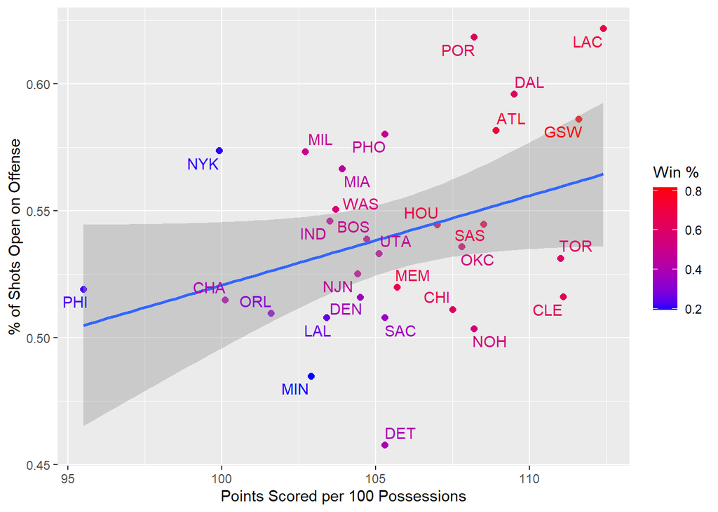

```r
ggplot(data=os_pct_offense, mapping=aes(x=ORtg, y=open_shot_pct, color=win_pct)) +
  geom_point(size=2) +
  geom_smooth(method = lm) +
  geom_text_repel(aes(label=bbr_team_id)) +
  labs(x = "Points Scored per 100 Possessions",
       y = "% of Shots Open on Offense",
       color = "Win %") +
  scale_color_gradient(low = "blue", high = "red")
```

```r
defensive_rating <- team_season%>%
  select(Tm, win_pct, DRtg) %>%
  rename(bbr_team_id = Tm)


os_pct_defense <- league_defense_summary %>%
  group_by(team) %>%
  summarise(
    opp_open_shot_pct = mean(opp_open_shot_pct)
  ) %>%
  arrange(desc(opp_open_shot_pct)) %>%
  left_join(defensive_rating, by=c("team"="bbr_team_id"))
```

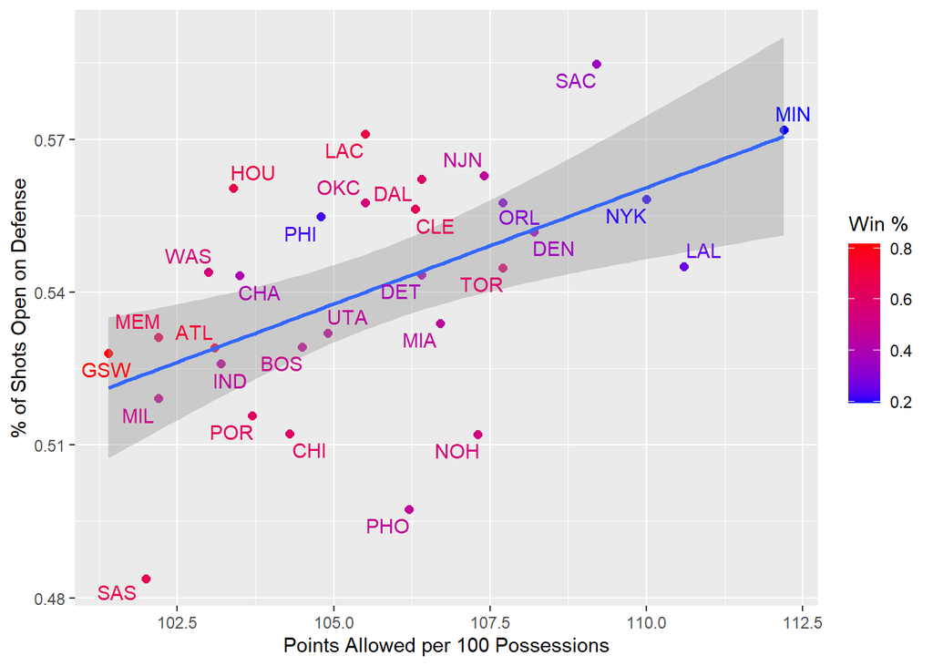

```r
ggplot(data=os_pct_defense, mapping=aes(x=DRtg, y=opp_open_shot_pct, color=win_pct)) +
  geom_point(size=2) +
  geom_smooth(method = lm) +
  geom_text_repel(aes(label=team)) +
  labs(x = "Points Allowed per 100 Possessions",
       y = "% of Shots Open on Defense",
       color = "Win %") +
  scale_color_gradient(low = "blue", high = "red")
```